# Assessing model agreement in wheat grain nitrogen content prediction - a use case

Leo Bastos & Adrian Correndo

2022-05-11

## 1 Introduction

The *`metrica`* package was developed to visualize and compute the level of agreement between observed ground-truth values and model-derived (e.g., mechanistic or empirical) predictions.

This package is intended to fit into the following workflow:

1. a data set containing the observed values is used to train a model
2. the trained model is used to generate predictions
3. a data frame containing at least the **observed** and model-**predicted** values is created
4. *`metrica`* package is used to compute goodness of fit and error metrics based on observed and predicted values
5. *`metrica`* package is used to visualize model fit and selected fit metrics

This vignette introduces the functionality of the *`metrica`* package applied to observed and model-predicted values of wheat grain nitrogen (N) content (in grams of N $m^{-2}$).

## 2 Wheat grain N content

Let’s begin by loading the packages needed.

```r
library(ggplot2)
library(dplyr)
library(metrica)
```

Now we load the `wheat` data set included in the `metrica` package.

```r
# Load
data(wheat)

# Printing first observations
head(wheat)
```

```
#>        pred    obs
#> 1  2.577314  2.544
#> 2  3.989590  4.831
#> 3  5.645253  6.121
#> 4 13.125101 10.960
#> 5  4.955917  5.767
#> 6  6.687800  8.222
```

This data set contains two columns:

- **pred**: model-predicted wheat grain N content, in g N $m^{-2}$,
- **obs**: ground-truth observed wheat grain N content, in g N $m^{-2}$

## 3 Visual assessment of agreement

### 3.1 Scatterplot of pred vs. obs

The simplest way to visually assess agreement between observed and predicted values is with a scatterplot.

We can use the function `scatter_plot()` from the *metrica* package to create a scatterplot.

The function requires specifying at least:

- the data frame object name (`data` argument)
- the name of the column containing observed values (`obs` argument)
- the name of the column containing predicted values (`pred` argument)

Besides a scatterplot, this function also adds to the plot the **1:1 line** (solid line) and the **linear regression line** (dashed line).

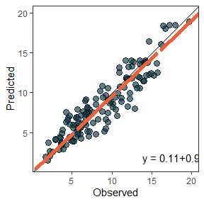

```r
scatter_plot(data = wheat,
             obs = obs,
             pred = pred)
```

The default behavior of `scatter_plot()` places the `obs` column on the x axis and the `pred` column on the y axis (`orientation = "PO"`). This can be inverted by changing the argument `orientation` to “OP”:

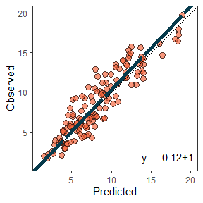

```r
scatter_plot(data = wheat,
             obs = obs,
             pred = pred,
             orientation = "OP")
```

The output of the `scatter_plot()` function is a `ggplot2` object that can be further customized:

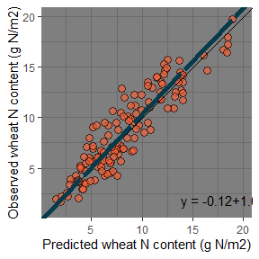

```r
scatter_plot(data = wheat,
             obs = obs,
             pred = pred,
             orientation = "OP")+
  labs(x ="Predicted wheat N content (g N/m2)",
       y = "Observed wheat N content (g N/m2)")+
  theme_dark()
```

## 3.2 Bland-Altman plot

The Bland-Altman plot is another way of visually assessing observed vs. predicted agreement. It plots the difference between observed and predicted values on the y axis, and the observed values on the x axis:

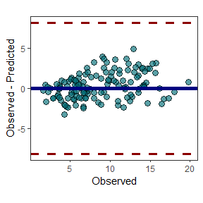

```r
bland_altman_plot(data = wheat,
                  obs = obs,
                  pred = pred)
```

## 4 Numerical assessment of agreement

The *metrica* package contains functions for **41 metrics** to assess agreement between observed and predicted values for continuous data (i.e., regression error).

A list with all the the metrics including their name, definition, details, formula, and function name, please check [here].

All of the metric functions take the same three arguments as the plotting functions:

- the data frame object name (`data` argument)
- the name of the column containing observed values (`obs` argument)
- the name of the column containing predicted values (`pred` argument)

The user can choose to calculate a single metric, or to calculate all metrics at once.

To calculate a single metric, the metric function can be called.  
For example, to calculate $R^{2}$, we can use the `R2()` function:

```r
R2(data = wheat,
   obs = obs,
   pred = pred)
```

```
#> [1] 0.8455538
```

Similarly, to calculate root mean squared error, we can use the `RMSE()` function:

```r
RMSE(data = wheat,
   obs = obs,
   pred = pred)
```

```
#> [1] 1.666441
```

The user can also calculate all 41 metrics at once using the function `metrics_summary()`:

```r
metrics_summary(data = wheat,
   obs = obs,
   pred = pred)
```

```
#>    Metric       Score
#> 1      B0  0.11315564
#> 2      B1  0.95057797
#> 3       r  0.91953997
#> 4      R2  0.84555376
#> 5      Xa  0.99564191
#> 6     CCC  0.91553253
#> 7     MAE  1.32781184
#> 8    RMAE  0.15214665
#> 9    MAPE 17.51424366
#> 10  SMAPE 17.43518492
#> 11    RAE  0.37156585
#> 12    RSE  0.16128874
#> 13    MBE  0.31815953
#> 14    PBE  3.64561486
```

[output cut: 27 more lines]

If the user wants just specific metrics, within the same function `metrics_summary()`, user can pass a list of desired metrics using the argument “metrics_list” as follows:

```r
my.metrics <- c("R2","MAE", "RMSE", "RSR", "NSE", "KGE")

metrics_summary(data = wheat,
                obs = obs,
                pred = pred,
                metrics_list = my.metrics)
```

```
#>   Metric      Score
#> 1     R2 0.84555376
#> 2    MAE 1.32781184
#> 3   RMSE 1.66644142
#> 4    RSR 0.09678632
#> 5    NSE 0.99999141
#> 6    KGE 0.91064709
```

## 5 Visual and numerical assessment combined

The user can also create a scatter plot that includes not only the **predicted** vs. **observed** points, **1:1 line**, and **regression line**, but also **selected metrics and their values** plus the **SMA regression equation**.

This is accomplished with the function `scatter_plot()`:

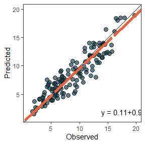

```r
scatter_plot(data = wheat,
             obs = obs,
             pred = pred)
```

To print the metrics on the `scatter_plot()`, just use print.metrics. Warning: do not forget to specify your ‘metrics.list’:

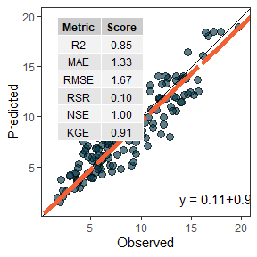

```r
my.metrica.plot <- scatter_plot(data = wheat,
             obs = obs,
             pred = pred,
             print_metrics = TRUE, metrics_list = my.metrics)

my.metrica.plot
```

Also, as a ggplot element, outputs are flexible of further edition:

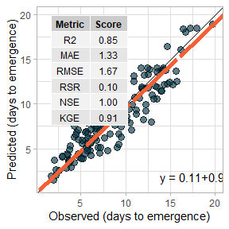

```r
my.metrica.plot +
  # Modify labels
  labs(x = "Observed (days to emergence)", y = "Predicted (days to emergence)")+
  # Modify theme
  theme_light()
```

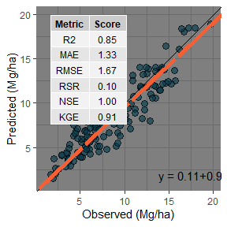

```r
my.metrica.plot +
  # Modify labels
  labs(x = "Observed (Mg/ha)", y = "Predicted (Mg/ha)")+
  # Modify theme
  theme_dark()
```

## 6 Exporting

To export the metrics summary table, the user can simply write it to file with the function `write.csv()`:

```r
metrics_summary(data = wheat,
   obs = obs,
   pred = pred) %>%
  write.csv("metrics_summary.csv")
```

Similarly, to export a plot, the user can simply write it to file with the function `ggsave()`:

```r
ggsave(plot = my.metrica.plot,
       "scatter_metrics.png",
       width = 5,
       height = 5)
```